# Generally Applicable Gene-set Enrichment (GAGE)

Oliver Hölsken

12.12.2021

The github repository can be found [here](https://github.com/ohoelske/MDS_KW4_GSE)

# Set up Working environment

## Installations

```r
if(!requireNamespace("BiocManager", quietly = TRUE))
  install.packages("BiocManager")
BiocManager::install(version = "3.14")
```

```r
#BiocManager::install(c("gage", "org.Hs.eg.db", "clusterProfiler"))
```

```r
#install.packages("msigdbr")
#install.packages("openxlsx")
```

## Load libraries

```r
library(BiocManager)
library(ggplot2)
library(ggrepel)
library(dplyr)
library(tibble)
library(readr)
library(tidyr)
library(tidyverse)
library(msigdbr)
library(clusterProfiler)
library(fgsea)
library(gage)
library(org.Hs.eg.db)
```

## Tasks

### Part 1: Getting familiar with Gene-sets

The Hallmark get can be found [here](https://www.gsea-msigdb.org/gsea/msigdb/genesets.jsp?collection=H).

1. Download Hallmark gene-sets using the `msigdbr` R package.

```r
#Check available gene sets using msigdbr_collections()
msigdbr_collections()
```

```
## # A tibble: 23 × 3
##    gs_cat gs_subcat         num_genesets
##    <chr>  <chr>                    <int>
##  1 C1     ""                         278
##  2 C2     "CGP"                     3368
##  3 C2     "CP"                        29
##  4 C2     "CP:BIOCARTA"              292
##  5 C2     "CP:KEGG"                  186
##  6 C2     "CP:PID"                   196
##  7 C2     "CP:REACTOME"             1604
##  8 C2     "CP:WIKIPATHWAYS"          615
##  9 C3     "MIR:MIR_Legacy"           221
## 10 C3     "MIR:MIRDB"               2377
## # … with 13 more rows
```

```r
# get Human H (Hallmark) gene sets
h_gene_set <- msigdbr(species = "human",
                      category = "H")
head(h_gene_set)
```

```
## # A tibble: 6 × 15
##   gs_cat gs_subcat gs_name gene_symbol entrez_gene ensembl_gene human_gene_symb…
##   <chr>  <chr>     <chr>   <chr>             <int> <chr>        <chr>
## 1 H      ""        HALLMA… ABCA1                19 ENSG0000016… ABCA1
## 2 H      ""        HALLMA… ABCB8             11194 ENSG0000019… ABCB8
## 3 H      ""        HALLMA… ACAA2             10449 ENSG0000016… ACAA2
## 4 H      ""        HALLMA… ACADL                33 ENSG0000011… ACADL
## 5 H      ""        HALLMA… ACADM                34 ENSG0000011… ACADM
## 6 H      ""        HALLMA… ACADS                35 ENSG0000012… ACADS
## # … with 8 more variables: human_entrez_gene <int>, human_ensembl_gene <chr>,
## #   gs_id <chr>, gs_pmid <chr>, gs_geoid <chr>, gs_exact_source <chr>,
## #   gs_url <chr>, gs_description <chr>
```

```r
# get Human Reactome gene sets
r_gene_set <- msigdbr(species = "human",
                      category = "C2",
                      subcategory = "CP:REACTOME")
head(h_gene_set)
```

```
## # A tibble: 6 × 15
##   gs_cat gs_subcat gs_name gene_symbol entrez_gene ensembl_gene human_gene_symb…
##   <chr>  <chr>     <chr>   <chr>             <int> <chr>        <chr>
## 1 H      ""        HALLMA… ABCA1                19 ENSG0000016… ABCA1
## 2 H      ""        HALLMA… ABCB8             11194 ENSG0000019… ABCB8
## 3 H      ""        HALLMA… ACAA2             10449 ENSG0000016… ACAA2
## 4 H      ""        HALLMA… ACADL                33 ENSG0000011… ACADL
## 5 H      ""        HALLMA… ACADM                34 ENSG0000011… ACADM
## 6 H      ""        HALLMA… ACADS                35 ENSG0000012… ACADS
## # … with 8 more variables: human_entrez_gene <int>, human_ensembl_gene <chr>,
## #   gs_id <chr>, gs_pmid <chr>, gs_geoid <chr>, gs_exact_source <chr>,
## #   gs_url <chr>, gs_description <chr>
```

2. Look at Hallmark: check the number of gene-sets, number of genes per gene set…

```r
# Create a nested data (list-column of a data frame)
n_h_gene_set <- h_gene_set %>%
  group_by(gs_name) %>%
  nest()
# Count no of rows = gene sets
nrow(n_h_gene_set)
```

```
## [1] 50
```

```r
n_h_gene_set
```

```
## # A tibble: 50 × 2
## # Groups:   gs_name [50]
##    gs_name                          data
##    <chr>                            <list>
##  1 HALLMARK_ADIPOGENESIS            <tibble [208 × 14]>
##  2 HALLMARK_ALLOGRAFT_REJECTION     <tibble [332 × 14]>
##  3 HALLMARK_ANDROGEN_RESPONSE       <tibble [102 × 14]>
##  4 HALLMARK_ANGIOGENESIS            <tibble [36 × 14]>
##  5 HALLMARK_APICAL_JUNCTION         <tibble [231 × 14]>
##  6 HALLMARK_APICAL_SURFACE          <tibble [46 × 14]>
##  7 HALLMARK_APOPTOSIS               <tibble [182 × 14]>
##  8 HALLMARK_BILE_ACID_METABOLISM    <tibble [114 × 14]>
##  9 HALLMARK_CHOLESTEROL_HOMEOSTASIS <tibble [77 × 14]>
## 10 HALLMARK_COAGULATION             <tibble [159 × 14]>
## # … with 40 more rows
```

The Hallmark Datasets contains 50 Gene-sets

```r
#Extract the Gene-set names
Gene_set_name <- n_h_gene_set$gs_name
head(Gene_set_name)
```

```
## [1] "HALLMARK_ADIPOGENESIS"        "HALLMARK_ALLOGRAFT_REJECTION"
## [3] "HALLMARK_ANDROGEN_RESPONSE"   "HALLMARK_ANGIOGENESIS"
## [5] "HALLMARK_APICAL_JUNCTION"     "HALLMARK_APICAL_SURFACE"
```

```r
#Define no of Genes per Gene set by using the purrr::map function
Genes_per_Gene_set <- map_int(n_h_gene_set$data, ~nrow(.))
```

```r
# Generate df
GS_genes <- data.frame(Gene_set_name, Genes_per_Gene_set)
head(GS_genes)
```

```
##                  Gene_set_name Genes_per_Gene_set
## 1        HALLMARK_ADIPOGENESIS                208
## 2 HALLMARK_ALLOGRAFT_REJECTION                332
## 3   HALLMARK_ANDROGEN_RESPONSE                102
## 4        HALLMARK_ANGIOGENESIS                 36
## 5     HALLMARK_APICAL_JUNCTION                231
## 6      HALLMARK_APICAL_SURFACE                 46
```

```r
knitr::kable(GS_genes,
caption = "Genes per Hallmark Geneset")
```

Genes per Hallmark Geneset

| Gene_set_name | Genes_per_Gene_set |
| --- | --- |
| HALLMARK_ADIPOGENESIS | 208 |
| HALLMARK_ALLOGRAFT_REJECTION | 332 |
| HALLMARK_ANDROGEN_RESPONSE | 102 |
| HALLMARK_ANGIOGENESIS | 36 |
| HALLMARK_APICAL_JUNCTION | 231 |
| HALLMARK_APICAL_SURFACE | 46 |
| HALLMARK_APOPTOSIS | 182 |
| HALLMARK_BILE_ACID_METABOLISM | 114 |
| HALLMARK_CHOLESTEROL_HOMEOSTASIS | 77 |
| HALLMARK_COAGULATION | 159 |
| HALLMARK_COMPLEMENT | 236 |
| HALLMARK_DNA_REPAIR | 169 |
| HALLMARK_E2F_TARGETS | 217 |
| HALLMARK_EPITHELIAL_MESENCHYMAL_TRANSITION | 203 |
| HALLMARK_ESTROGEN_RESPONSE_EARLY | 216 |
| HALLMARK_ESTROGEN_RESPONSE_LATE | 218 |
| HALLMARK_FATTY_ACID_METABOLISM | 165 |
| HALLMARK_G2M_CHECKPOINT | 204 |
| HALLMARK_GLYCOLYSIS | 211 |
| HALLMARK_HEDGEHOG_SIGNALING | 36 |
| HALLMARK_HEME_METABOLISM | 214 |
| HALLMARK_HYPOXIA | 213 |
| HALLMARK_IL2_STAT5_SIGNALING | 216 |
| HALLMARK_IL6_JAK_STAT3_SIGNALING | 103 |
| HALLMARK_INFLAMMATORY_RESPONSE | 222 |
| HALLMARK_INTERFERON_ALPHA_RESPONSE | 139 |
| HALLMARK_INTERFERON_GAMMA_RESPONSE | 284 |
| HALLMARK_KRAS_SIGNALING_DN | 219 |
| HALLMARK_KRAS_SIGNALING_UP | 220 |
| HALLMARK_MITOTIC_SPINDLE | 215 |
| HALLMARK_MTORC1_SIGNALING | 210 |
| HALLMARK_MYC_TARGETS_V1 | 230 |
| HALLMARK_MYC_TARGETS_V2 | 60 |
| HALLMARK_MYOGENESIS | 211 |
| HALLMARK_NOTCH_SIGNALING | 34 |
| HALLMARK_OXIDATIVE_PHOSPHORYLATION | 220 |
| HALLMARK_P53_PATHWAY | 214 |
| HALLMARK_PANCREAS_BETA_CELLS | 44 |
| HALLMARK_PEROXISOME | 110 |
| HALLMARK_PI3K_AKT_MTOR_SIGNALING | 117 |
| HALLMARK_PROTEIN_SECRETION | 97 |
| HALLMARK_REACTIVE_OXYGEN_SPECIES_PATHWAY | 58 |
| HALLMARK_SPERMATOGENESIS | 144 |
| HALLMARK_TGF_BETA_SIGNALING | 59 |
| HALLMARK_TNFA_SIGNALING_VIA_NFKB | 227 |
| HALLMARK_UNFOLDED_PROTEIN_RESPONSE | 115 |
| HALLMARK_UV_RESPONSE_DN | 152 |
| HALLMARK_UV_RESPONSE_UP | 189 |
| HALLMARK_WNT_BETA_CATENIN_SIGNALING | 50 |
| HALLMARK_XENOBIOTIC_METABOLISM | 224 |

3. Prepare a figure (e.g. barplot) showing the number of genes per gene set.

```r
#Transform data frame to remove "Hallmark" string
GS_genes$Gene_set_name <-
  gsub("HALLMARK_","",as.character(GS_genes$Gene_set_name))
head(GS_genes)
```

```
##         Gene_set_name Genes_per_Gene_set
## 1        ADIPOGENESIS                208
## 2 ALLOGRAFT_REJECTION                332
## 3   ANDROGEN_RESPONSE                102
## 4        ANGIOGENESIS                 36
## 5     APICAL_JUNCTION                231
## 6      APICAL_SURFACE                 46
```

```r
#Change factor lavels to order according to no of genes per Gene set
GS_genes$Gene_set_name <- factor(GS_genes$Gene_set_name,
                                 levels = GS_genes$Gene_set_name
                                 [order(GS_genes$Genes_per_Gene_set)])
```

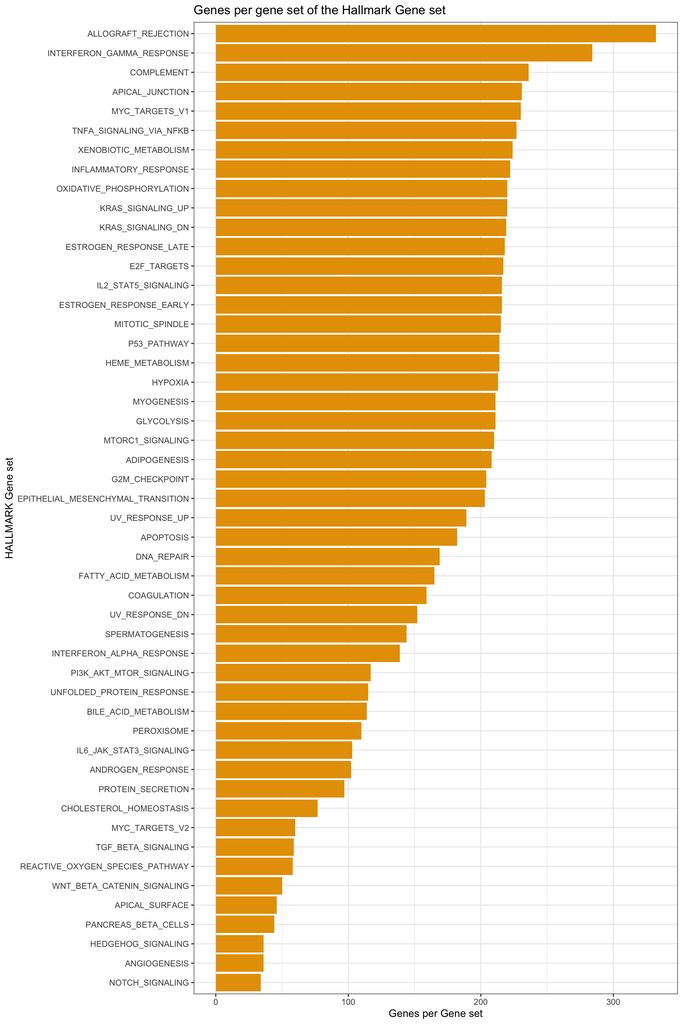

Genes per gene-set

```r
#Create the Bar Plot
x <- ggplot(GS_genes, aes(x = Gene_set_name, y = Genes_per_Gene_set)) +
  theme_bw() +
  geom_bar(stat = "identity", fill="#E69F00") +
  coord_flip()
x + ggtitle("Genes per gene set of the Hallmark Gene set") +
  xlab("HALLMARK Gene set") +
  ylab("Genes per Gene set")
```

```r
#Save as PDF
ggsave(
  file = "GenesPerGeneset.pdf",
  plot = last_plot(),
  path = NULL,
  scale = 1,
  width = 10,
  height = 15,
  units = "in",
  dpi = "retina",
  limitsize = TRUE,
  bg = NULL,
)
```

4. Convert the hallmark `data.frame` into a named list (to be used as “gsets” parameter with gage) (For this, the `readList` function was used from the downloaded `.gmt` files. This is probably not the most elegant way but it served its purpose I hope.)

```r
#Read in Database information as List
hallmarks_symbols <- readList("h.all.v7.4.symbols.gmt")
hallmarks_entrez <- readList("h.all.v7.4.entrez.gmt")
```

5. Do the same with the `Reactome` database

```r
reactome_entrez <- readList("c2.cp.reactome.v7.4.entrez.gmt")
reactome_symbol <- readList("c2.cp.reactome.v7.4.symbols.gmt")
```

### Part 2:

Now we are preparing the gene-expression data.

1. Load the hallmark list you have created

```r
hallmark_list <- hallmarks_entrez
```

2. Load the log2 TPM matrix.

```r
expr.data <- read.delim("TCGA_GBM_log2TPM.txt")
expr.data <- as.data.frame(expr.data)
head(expr.data)
```

```
##       Normal_0675 Normal_0678 Normal_0680 Normal_0681 Normal_AABW Primary_0125
## 7105    4.0903371   3.7516770   4.1518141   3.8727898    3.541913    6.6865540
## 64102   0.3128999   0.2129448   0.1863435   0.3328771    0.000000    0.2631846
## 8813    5.2721045   5.2509175   5.1153253   5.3192045    4.936058    5.6664555
## 57147   3.1824658   2.9652870   3.3310549   3.0674177    3.191533    3.0979871
## 55732   1.1064375   1.0135309   1.1332443   1.2390343    1.618687    2.7639647
## 2268    2.2827262   3.1784475   2.3382873   2.5207448    1.940340    2.4557458
##       Primary_0184 Primary_0190 Primary_0210 Primary_0211 Recurrent_0171
## 7105     7.0246342    6.5278105   6.88528347    6.8510418       5.500578
## 64102    0.2893416    0.1902568   0.09940081    0.1565262       0.104506
## 8813     5.2539728    5.3711918   5.49613715    5.5049994       5.025693
## 57147    2.6402659    2.7481366   2.82314147    3.0626336       2.904430
## 55732    1.9892013    2.9332447   2.03837616    3.0687751       1.996929
## 2268     4.0677962    4.0805542   4.24732007    2.8701856       5.567501
##       Recurrent_0190 Recurrent_0210 Recurrent_0211 Recurrent_0221
## 7105        5.805603      6.1838272      6.4730714     5.65474845
## 64102       0.648461      0.3960793      0.2758985     0.09542196
## 8813        5.492856      4.9039430      5.9053705     5.21591963
## 57147       2.571341      2.9093370      2.8634424     3.40746406
## 55732       2.670986      2.5211307      2.4087028     3.01843760
## 2268        3.120462      3.7357202      3.4580312     2.29577096
```

```r
#convert the data.frame into a matrix as to speed up the computing
expr.data.matr <- as.matrix(expr.data)
str(expr.data.matr)
```

```
##  num [1:26262, 1:15] 4.09 0.313 5.272 3.182 1.106 ...
##  - attr(*, "dimnames")=List of 2
##   ..$ : chr [1:26262] "7105" "64102" "8813" "57147" ...
##   ..$ : chr [1:15] "Normal_0675" "Normal_0678" "Normal_0680" "Normal_0681" ...
```

3. Check the overlap between the database and the genes within the RNA matrix

```r
head(hallmark_list[[1]]); head(rownames(expr.data.matr))
```

```
## [1] "3726" "2920" "467"  "4792" "7128" "5743"
```

```
## [1] "7105"  "64102" "8813"  "57147" "55732" "2268"
```

gene ID types are the same in the gene sets `hallmark_list` and expression data`expr.data.mat`

4. Create an annotation `data.frame` from the column names of the RNA matrix (i.e. assign each sample to either primary, recurrent or normal condition).

```r
my_sample_col <- data.frame(condition = rep(c("Normal", "Primary", "Recurrent"),
                                            c(5,5,5)))
row.names(my_sample_col) <- colnames(expr.data)
my_sample_col
```

```
##                condition
## Normal_0675       Normal
## Normal_0678       Normal
## Normal_0680       Normal
## Normal_0681       Normal
## Normal_AABW       Normal
## Primary_0125     Primary
## Primary_0184     Primary
## Primary_0190     Primary
## Primary_0210     Primary
## Primary_0211     Primary
## Recurrent_0171 Recurrent
## Recurrent_0190 Recurrent
## Recurrent_0210 Recurrent
## Recurrent_0211 Recurrent
## Recurrent_0221 Recurrent
```

```r
# Check if all rownames from annotated sample column are equal to colnames of the expression data
all(rownames(my_sample_col) == colnames(expr.data))
```

```
## [1] TRUE
```

```r
head(expr.data)
```

```
##       Normal_0675 Normal_0678 Normal_0680 Normal_0681 Normal_AABW Primary_0125
## 7105    4.0903371   3.7516770   4.1518141   3.8727898    3.541913    6.6865540
## 64102   0.3128999   0.2129448   0.1863435   0.3328771    0.000000    0.2631846
## 8813    5.2721045   5.2509175   5.1153253   5.3192045    4.936058    5.6664555
## 57147   3.1824658   2.9652870   3.3310549   3.0674177    3.191533    3.0979871
## 55732   1.1064375   1.0135309   1.1332443   1.2390343    1.618687    2.7639647
## 2268    2.2827262   3.1784475   2.3382873   2.5207448    1.940340    2.4557458
##       Primary_0184 Primary_0190 Primary_0210 Primary_0211 Recurrent_0171
## 7105     7.0246342    6.5278105   6.88528347    6.8510418       5.500578
## 64102    0.2893416    0.1902568   0.09940081    0.1565262       0.104506
## 8813     5.2539728    5.3711918   5.49613715    5.5049994       5.025693
## 57147    2.6402659    2.7481366   2.82314147    3.0626336       2.904430
## 55732    1.9892013    2.9332447   2.03837616    3.0687751       1.996929
## 2268     4.0677962    4.0805542   4.24732007    2.8701856       5.567501
##       Recurrent_0190 Recurrent_0210 Recurrent_0211 Recurrent_0221
## 7105        5.805603      6.1838272      6.4730714     5.65474845
## 64102       0.648461      0.3960793      0.2758985     0.09542196
## 8813        5.492856      4.9039430      5.9053705     5.21591963
## 57147       2.571341      2.9093370      2.8634424     3.40746406
## 55732       2.670986      2.5211307      2.4087028     3.01843760
## 2268        3.120462      3.7357202      3.4580312     2.29577096
```

5. Calculate the average log2 foldchange between primary and normal, recurrent and normal, recurrent and primary.

```r
#calculate the mean for each gene per group
normal_mean <- apply(expr.data[,1:5],1, mean)
primary_mean <- apply(expr.data[,6:10],1, mean)
recurrent_mean <- apply(expr.data[,11:15],1, mean)
```

```r
#calculate the fold change between the groups
## Normal/Primary
foldchange_nor_primary <- normal_mean - primary_mean
## Normal/Recurrent
foldchange_nor_recurrent <- normal_mean - recurrent_mean
## Primary/Recurrent
foldchange_pri_recurrent <- primary_mean - recurrent_mean
```

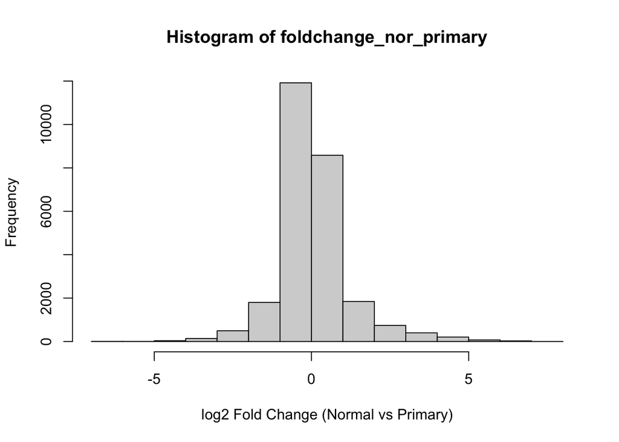

```r
hist(foldchange_nor_primary,
     xlab = "log2 Fold Change (Normal vs Primary)")
```

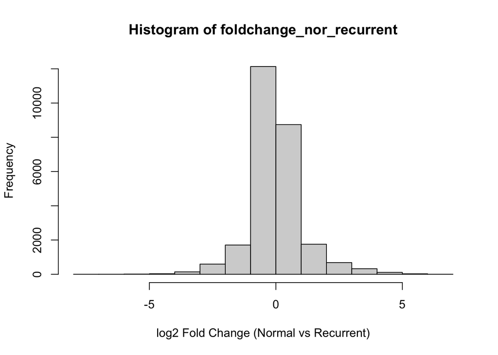

```r
hist(foldchange_nor_recurrent,
     xlab = "log2 Fold Change (Normal vs Recurrent)")
```

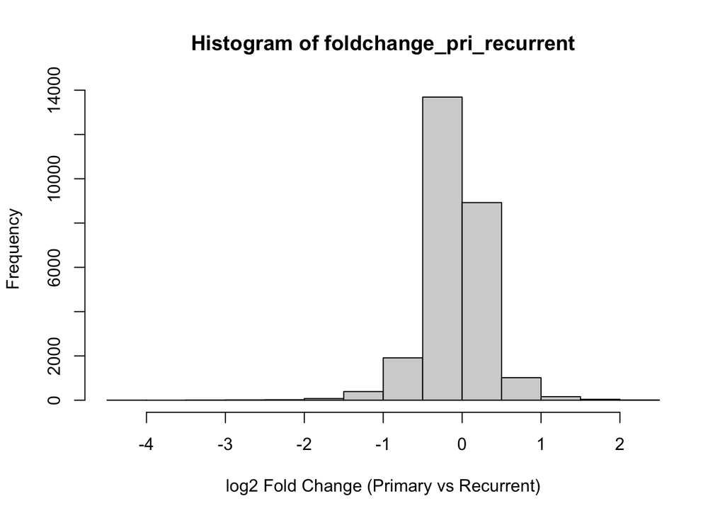

```r
hist(foldchange_pri_recurrent,
     xlab = "log2 Fold Change (Primary vs Recurrent)")
```

```r
#Add log2FC for normal/tumor
expr.data.fc <- expr.data
expr.data.fc$log2FC_nor_pri <- foldchange_nor_primary
expr.data.fc$log2FC_nor_rec <- foldchange_nor_recurrent
expr.data.fc$log2FC_pri_recurrent <- foldchange_pri_recurrent
expr.data.fc <- rownames_to_column(expr.data.fc, var = "gene_ID")
```

```r
# add Gene_Symbol
library("gage")
data(egSymb)
expr.data.fc$Gene_Symbol <- eg2sym(expr.data.fc$gene_ID)
head(expr.data.fc)
```

```
##   gene_ID Normal_0675 Normal_0678 Normal_0680 Normal_0681 Normal_AABW
## 1    7105   4.0903371   3.7516770   4.1518141   3.8727898    3.541913
## 2   64102   0.3128999   0.2129448   0.1863435   0.3328771    0.000000
## 3    8813   5.2721045   5.2509175   5.1153253   5.3192045    4.936058
## 4   57147   3.1824658   2.9652870   3.3310549   3.0674177    3.191533
## 5   55732   1.1064375   1.0135309   1.1332443   1.2390343    1.618687
## 6    2268   2.2827262   3.1784475   2.3382873   2.5207448    1.940340
##   Primary_0125 Primary_0184 Primary_0190 Primary_0210 Primary_0211
## 1    6.6865540    7.0246342    6.5278105   6.88528347    6.8510418
## 2    0.2631846    0.2893416    0.1902568   0.09940081    0.1565262
## 3    5.6664555    5.2539728    5.3711918   5.49613715    5.5049994
## 4    3.0979871    2.6402659    2.7481366   2.82314147    3.0626336
## 5    2.7639647    1.9892013    2.9332447   2.03837616    3.0687751
## 6    2.4557458    4.0677962    4.0805542   4.24732007    2.8701856
##   Recurrent_0171 Recurrent_0190 Recurrent_0210 Recurrent_0211 Recurrent_0221
## 1       5.500578       5.805603      6.1838272      6.4730714     5.65474845
## 2       0.104506       0.648461      0.3960793      0.2758985     0.09542196
## 3       5.025693       5.492856      4.9039430      5.9053705     5.21591963
## 4       2.904430       2.571341      2.9093370      2.8634424     3.40746406
## 5       1.996929       2.670986      2.5211307      2.4087028     3.01843760
## 6       5.567501       3.120462      3.7357202      3.4580312     2.29577096
##   log2FC_nor_pri log2FC_nor_rec log2FC_pri_recurrent Gene_Symbol
## 1   -2.913358608    -2.04185940           0.87149921      TSPAN6
## 2    0.009271052    -0.09506031          -0.10433136        TNMD
## 3   -0.279829313    -0.13003442           0.14979489        DPM1
## 4    0.273118833     0.21634875          -0.05677008       SCYL3
## 5   -1.336525652    -1.30105035           0.03547530    C1orf112
## 6   -1.092211244    -1.18338796          -0.09117671         FGR
```

```r
#Select genes, which are upregulated in expression matrix (normal vs. primary)
genes.up_pri_no <- subset(expr.data.fc,
                          log2FC_nor_pri > 0,
                          select = c("Gene_Symbol", "gene_ID"))
head(genes.up_pri_no)
```

```
##    Gene_Symbol gene_ID
## 2         TNMD   64102
## 4        SCYL3   57147
## 9         GCLC    2729
## 10        NFYA    4800
## 11    C1orf201   90529
## 12       NPAL3   57185
```

```r
up_genes <- genes.up_pri_no$gene_ID
```

```r
#Select genes, which are downregulated in expxression matrix (normal vs. primary)
genes.down_pri_no <- subset(expr.data.fc,
                            log2FC_nor_pri < 0,
                            select = c("Gene_Symbol", "gene_ID"))
head(genes.down_pri_no)
```

```
##   Gene_Symbol gene_ID
## 1      TSPAN6    7105
## 3        DPM1    8813
## 5    C1orf112   55732
## 6         FGR    2268
## 7         CFH    3075
## 8       FUCA2    2519
```

```r
down_genes <- genes.down_pri_no$gene_ID
```

```r
#Select genes, which are up/downregulated in epxression matrix (normal vs. recurrent)
## Upregulated
genes.up_nor_rec <- subset(expr.data.fc,
                           log2FC_nor_rec >0,
                           select = c("Gene_Symbol", "gene_ID"))
## down
genes.down_nor_rec <- subset(expr.data.fc,
                           log2FC_nor_rec <0,
                           select = c("Gene_Symbol", "gene_ID"))
#Select genes, which are up/downregulated in epxression matrix (primary vs. recurrent)
## Upregulated
genes.up_pri_rec <- subset(expr.data.fc,
                           log2FC_pri_recurrent >0,
                           select = c("Gene_Symbol", "gene_ID"))
## down
genes.down_pri_rec <- subset(expr.data.fc,
                           log2FC_pri_recurrent <0,
                           select = c("Gene_Symbol", "gene_ID"))
```

6. Use `Gage` (unpaired test) to identify differentially UP- and DOWN-regulated gene-sets (using `Hallmark` and `Reactome` gene-sets separately). Make the following comparisons: primary vs. normal, recurrent vs. normal, recurrent vs. primary.

```r
#Definition of gage inputs
cn <- colnames(expr.data)
normal <- grep('Normal',cn, ignore.case =T)
primary <- grep('Primary',cn, ignore.case =T)
recurrent <- grep('Recurrent',cn, ignore.case =T)
```

```r
#Hallmarks
gage_H_pri_no = gage(exprs = expr.data,
                     gsets = hallmark_list,
                     set.size=c(10,500),
                     same.dir = TRUE,
                     compare ="unpaired",
                     ref = normal,
                     samp = primary)

gage_H_rec_no = gage(exprs = expr.data,
                     gsets = hallmark_list,
                     set.size=c(10,500),
                     same.dir = TRUE,
                     compare ="unpaired",
                     ref = normal,
                     samp = recurrent)

gage_H_pri_rec = gage(exprs = expr.data,
                      gsets = hallmark_list,
                      set.size=c(10,500),
                      same.dir = TRUE,
                      compare ="unpaired",
                      ref = primary,
                      samp = recurrent)
```

```r
#Reactome database
gage_R_pri_no = gage(exprs = expr.data,
                     gsets = reactome_entrez,
                     set.size=c(10,500),
                     same.dir = TRUE,
                     compare ="unpaired",
                     ref = normal,
                     samp = primary)

gage_R_rec_no = gage(exprs = expr.data,
                     gsets = reactome_entrez,
                     set.size=c(10,500),
                     same.dir = TRUE,
                     compare ="unpaired",
                     ref = normal,
                     samp = recurrent)

gage_R_pri_rec = gage(exprs = expr.data,
                      gsets = reactome_entrez,
                      set.size=c(10,500),
                      same.dir = TRUE,
                      compare ="unpaired",
                      ref = primary,
                      samp = recurrent)
```

```r
#Determine the significant gene sets by using the sigGeneSetFunction.
no_pri_H.sig<-sigGeneSet(gage_H_pri_no, cutoff = 0.1)
```

```
## [1] "there are 30 signficantly up-regulated gene sets"
## [1] "there are 5 signficantly down-regulated gene sets"
```

```r
no_rec_H.sig<-sigGeneSet(gage_H_rec_no, cutoff = 0.1)
```

```
## [1] "there are 33 signficantly up-regulated gene sets"
## [1] "there are 3 signficantly down-regulated gene sets"
```

```r
pri_rec_H.sig<-sigGeneSet(gage_H_pri_rec, cutoff = 0.1)
```

```
## [1] "there are 15 signficantly up-regulated gene sets"
## [1] "there are 6 signficantly down-regulated gene sets"
```

```r
#Do the same for the reactome dataset
no_pri_R.sig<-sigGeneSet(gage_R_pri_no, cutoff = 0.1)
```

```
## [1] "there are 537 signficantly up-regulated gene sets"
## [1] "there are 207 signficantly down-regulated gene sets"
```

```r
no_rec_R.sig<-sigGeneSet(gage_R_rec_no, cutoff = 0.1)
```

```
## [1] "there are 530 signficantly up-regulated gene sets"
## [1] "there are 167 signficantly down-regulated gene sets"
```

```r
pri_rec_R.sig<-sigGeneSet(gage_R_pri_rec, cutoff = 0.1)
```

```
## [1] "there are 91 signficantly up-regulated gene sets"
## [1] "there are 45 signficantly down-regulated gene sets"
```

```r
#UpregulatesGene sets Normal vs. Primary as data frame
df_no_pri_H.sig <- as.data.frame(no_pri_H.sig$greater)
df_no_pri_H.sig <- subset(df_no_pri_H.sig,
                          select = c("p.val","q.val","set.size"))
head(df_no_pri_H.sig)
```

```
##                                                   p.val        q.val set.size
## HALLMARK_E2F_TARGETS                       1.950754e-83 9.753772e-82      198
## HALLMARK_EPITHELIAL_MESENCHYMAL_TRANSITION 1.823530e-58 4.558826e-57      198
## HALLMARK_G2M_CHECKPOINT                    5.291214e-55 8.818690e-54      198
## HALLMARK_INTERFERON_GAMMA_RESPONSE         7.445054e-53 9.306317e-52      196
## HALLMARK_MYC_TARGETS_V1                    1.103913e-42 1.103913e-41      198
## HALLMARK_ALLOGRAFT_REJECTION               3.306513e-33 2.755428e-32      194
```

```r
#DownregulatesGene sets Normal vs. Primary as data frame
df_no_pri_H.sig.down <- as.data.frame(no_pri_H.sig$less)
df_no_pri_H.sig.down <- subset(df_no_pri_H.sig.down,
                          select = c("p.val","q.val","set.size"))
head(df_no_pri_H.sig.down)
```

```
##                                         p.val        q.val set.size
## HALLMARK_KRAS_SIGNALING_DN       3.550289e-13 1.775144e-11      195
## HALLMARK_HEME_METABOLISM         5.526475e-04 1.381619e-02      195
## HALLMARK_SPERMATOGENESIS         3.801813e-03 6.336355e-02      135
## HALLMARK_PANCREAS_BETA_CELLS     5.485485e-03 6.856857e-02       39
## HALLMARK_ESTROGEN_RESPONSE_EARLY 7.217882e-03 7.217882e-02      199
```

```r
#Create annotated Hallmark list
library(purrr)
#Upregulated genes
intersect_up_genes <- function(x) intersect(x, up_genes)
annotated_hallmarks_up <- map(hallmark_list, intersect_up_genes)
#Downregulated genes
intersect_down_genes <- function(x) intersect(x, down_genes)
annotated_hallmarks_down  <- map(hallmark_list, intersect_down_genes)
```

```r
#UP df
up_list <- t(map_dfc(annotated_hallmarks_up, ~length(.)))
up_df <- as.data.frame(up_list)
colnames(up_df)[colnames(up_df ) == "V1"] <- "nb"
up_df
```

```
##                                             nb
## HALLMARK_TNFA_SIGNALING_VIA_NFKB            49
## HALLMARK_HYPOXIA                            70
## HALLMARK_CHOLESTEROL_HOMEOSTASIS            32
## HALLMARK_MITOTIC_SPINDLE                   108
## HALLMARK_WNT_BETA_CATENIN_SIGNALING         17
## HALLMARK_TGF_BETA_SIGNALING                 22
## HALLMARK_IL6_JAK_STAT3_SIGNALING            14
## HALLMARK_DNA_REPAIR                         45
## HALLMARK_G2M_CHECKPOINT                     52
## HALLMARK_APOPTOSIS                          50
## HALLMARK_NOTCH_SIGNALING                    10
## HALLMARK_ADIPOGENESIS                      103
## HALLMARK_ESTROGEN_RESPONSE_EARLY           112
## HALLMARK_ESTROGEN_RESPONSE_LATE            105
## HALLMARK_ANDROGEN_RESPONSE                  50
## HALLMARK_MYOGENESIS                        112
## HALLMARK_PROTEIN_SECRETION                  45
## HALLMARK_INTERFERON_ALPHA_RESPONSE          19
## HALLMARK_INTERFERON_GAMMA_RESPONSE          36
## HALLMARK_APICAL_JUNCTION                    96
## HALLMARK_APICAL_SURFACE                     24
## HALLMARK_HEDGEHOG_SIGNALING                 21
## HALLMARK_COMPLEMENT                         70
## HALLMARK_UNFOLDED_PROTEIN_RESPONSE          36
## HALLMARK_PI3K_AKT_MTOR_SIGNALING            48
## HALLMARK_MTORC1_SIGNALING                   77
## HALLMARK_E2F_TARGETS                        29
## HALLMARK_MYC_TARGETS_V1                     41
## HALLMARK_MYC_TARGETS_V2                     17
## HALLMARK_EPITHELIAL_MESENCHYMAL_TRANSITION  40
## HALLMARK_INFLAMMATORY_RESPONSE              57
## HALLMARK_XENOBIOTIC_METABOLISM              88
## HALLMARK_FATTY_ACID_METABOLISM              82
## HALLMARK_OXIDATIVE_PHOSPHORYLATION         117
## HALLMARK_GLYCOLYSIS                         69
## HALLMARK_REACTIVE_OXYGEN_SPECIES_PATHWAY    21
## HALLMARK_P53_PATHWAY                        77
## HALLMARK_UV_RESPONSE_UP                     78
## HALLMARK_UV_RESPONSE_DN                     81
## HALLMARK_ANGIOGENESIS                        6
## HALLMARK_HEME_METABOLISM                   107
## HALLMARK_COAGULATION                        49
## HALLMARK_IL2_STAT5_SIGNALING                69
## HALLMARK_BILE_ACID_METABOLISM               61
## HALLMARK_PEROXISOME                         55
## HALLMARK_ALLOGRAFT_REJECTION                43
## HALLMARK_SPERMATOGENESIS                    91
## HALLMARK_KRAS_SIGNALING_UP                  74
## HALLMARK_KRAS_SIGNALING_DN                 134
## HALLMARK_PANCREAS_BETA_CELLS                18
```

```r
library(tibble)
ned_df_2 <- rownames_to_column(df_no_pri_H.sig)
ned_df_3 <- rownames_to_column(up_df)
```

```r
#Create the final table with upregulated genes
final_df_up <- inner_join(ned_df_2, ned_df_3, by = "rowname", copy = FALSE)
colnames(final_df_up )[1] <- "Gene_set"
final_df_up$log10p.val <- -log10(final_df_up$p.val)
head(final_df_up)
```

```
##                                     Gene_set        p.val        q.val set.size
## 1                       HALLMARK_E2F_TARGETS 1.950754e-83 9.753772e-82      198
## 2 HALLMARK_EPITHELIAL_MESENCHYMAL_TRANSITION 1.823530e-58 4.558826e-57      198
## 3                    HALLMARK_G2M_CHECKPOINT 5.291214e-55 8.818690e-54      198
## 4         HALLMARK_INTERFERON_GAMMA_RESPONSE 7.445054e-53 9.306317e-52      196
## 5                    HALLMARK_MYC_TARGETS_V1 1.103913e-42 1.103913e-41      198
## 6               HALLMARK_ALLOGRAFT_REJECTION 3.306513e-33 2.755428e-32      194
##   nb log10p.val
## 1 29   82.70980
## 2 40   57.73909
## 3 52   54.27644
## 4 36   52.12813
## 5 41   41.95707
## 6 43   32.48063
```

```r
knitr::kable(final_df_up,
caption = "Significantly upregulated Gene sets (Normal / Tumor)")
```

Significantly upregulated Gene sets (Normal / Tumor)

| Gene_set | p.val | q.val | set.size | nb | log10p.val |
| --- | --- | --- | --- | --- | --- |
| HALLMARK_E2F_TARGETS | 0.0000000 | 0.0000000 | 198 | 29 | 82.709797 |
| HALLMARK_EPITHELIAL_MESENCHYMAL_TRANSITION | 0.0000000 | 0.0000000 | 198 | 40 | 57.739087 |
| HALLMARK_G2M_CHECKPOINT | 0.0000000 | 0.0000000 | 198 | 52 | 54.276445 |
| HALLMARK_INTERFERON_GAMMA_RESPONSE | 0.0000000 | 0.0000000 | 196 | 36 | 52.128132 |
| HALLMARK_MYC_TARGETS_V1 | 0.0000000 | 0.0000000 | 198 | 41 | 41.957065 |
| HALLMARK_ALLOGRAFT_REJECTION | 0.0000000 | 0.0000000 | 194 | 43 | 32.480630 |
| HALLMARK_TNFA_SIGNALING_VIA_NFKB | 0.0000000 | 0.0000000 | 197 | 49 | 30.945979 |
| HALLMARK_INTERFERON_ALPHA_RESPONSE | 0.0000000 | 0.0000000 | 95 | 19 | 25.379804 |
| HALLMARK_IL6_JAK_STAT3_SIGNALING | 0.0000000 | 0.0000000 | 85 | 14 | 23.685049 |
| HALLMARK_COAGULATION | 0.0000000 | 0.0000000 | 133 | 49 | 21.166924 |
| HALLMARK_HYPOXIA | 0.0000000 | 0.0000000 | 199 | 70 | 19.108286 |
| HALLMARK_INFLAMMATORY_RESPONSE | 0.0000000 | 0.0000000 | 196 | 57 | 18.735436 |
| HALLMARK_ANGIOGENESIS | 0.0000000 | 0.0000000 | 36 | 6 | 16.786570 |
| HALLMARK_IL2_STAT5_SIGNALING | 0.0000000 | 0.0000000 | 196 | 69 | 14.174046 |
| HALLMARK_APOPTOSIS | 0.0000000 | 0.0000000 | 160 | 50 | 14.145511 |
| HALLMARK_GLYCOLYSIS | 0.0000000 | 0.0000000 | 199 | 69 | 13.976061 |
| HALLMARK_DNA_REPAIR | 0.0000000 | 0.0000000 | 147 | 45 | 12.948173 |
| HALLMARK_MTORC1_SIGNALING | 0.0000000 | 0.0000000 | 198 | 77 | 12.665593 |
| HALLMARK_COMPLEMENT | 0.0000000 | 0.0000000 | 192 | 70 | 11.753113 |
| HALLMARK_P53_PATHWAY | 0.0000000 | 0.0000000 | 196 | 77 | 8.782119 |
| HALLMARK_MYC_TARGETS_V2 | 0.0000000 | 0.0000000 | 58 | 17 | 7.834663 |
| HALLMARK_UNFOLDED_PROTEIN_RESPONSE | 0.0000003 | 0.0000007 | 112 | 36 | 6.503693 |
| HALLMARK_KRAS_SIGNALING_UP | 0.0000016 | 0.0000035 | 194 | 74 | 5.790676 |
| HALLMARK_TGF_BETA_SIGNALING | 0.0000149 | 0.0000311 | 54 | 22 | 4.825559 |
| HALLMARK_NOTCH_SIGNALING | 0.0001789 | 0.0003577 | 32 | 10 | 3.747480 |
| HALLMARK_CHOLESTEROL_HOMEOSTASIS | 0.0011508 | 0.0022131 | 74 | 32 | 2.938991 |
| HALLMARK_XENOBIOTIC_METABOLISM | 0.0011964 | 0.0022156 | 197 | 88 | 2.922124 |
| HALLMARK_WNT_BETA_CATENIN_SIGNALING | 0.0068602 | 0.0122504 | 42 | 17 | 2.163663 |
| HALLMARK_ADIPOGENESIS | 0.0087792 | 0.0147274 | 196 | 103 | 2.056545 |
| HALLMARK_MITOTIC_SPINDLE | 0.0088364 | 0.0147274 | 196 | 108 | 2.053724 |

Perform for downregulated genes

```r
#down df
down_list <- t(map_dfc(annotated_hallmarks_down, ~length(.)))
down_df <- as.data.frame(down_list)
colnames(down_df)[colnames(down_df ) == "V1"] <- "nb"
down_df
```

```
##                                             nb
## HALLMARK_TNFA_SIGNALING_VIA_NFKB           148
## HALLMARK_HYPOXIA                           128
## HALLMARK_CHOLESTEROL_HOMEOSTASIS            42
## HALLMARK_MITOTIC_SPINDLE                    88
## HALLMARK_WNT_BETA_CATENIN_SIGNALING         25
## HALLMARK_TGF_BETA_SIGNALING                 32
## HALLMARK_IL6_JAK_STAT3_SIGNALING            71
## HALLMARK_DNA_REPAIR                        102
## HALLMARK_G2M_CHECKPOINT                    146
## HALLMARK_APOPTOSIS                         110
## HALLMARK_NOTCH_SIGNALING                    22
## HALLMARK_ADIPOGENESIS                       93
## HALLMARK_ESTROGEN_RESPONSE_EARLY            86
## HALLMARK_ESTROGEN_RESPONSE_LATE             94
## HALLMARK_ANDROGEN_RESPONSE                  48
## HALLMARK_MYOGENESIS                         83
## HALLMARK_PROTEIN_SECRETION                  49
## HALLMARK_INTERFERON_ALPHA_RESPONSE          76
## HALLMARK_INTERFERON_GAMMA_RESPONSE         160
## HALLMARK_APICAL_JUNCTION                   100
## HALLMARK_APICAL_SURFACE                     19
## HALLMARK_HEDGEHOG_SIGNALING                 15
## HALLMARK_COMPLEMENT                        122
## HALLMARK_UNFOLDED_PROTEIN_RESPONSE          75
## HALLMARK_PI3K_AKT_MTOR_SIGNALING            56
## HALLMARK_MTORC1_SIGNALING                  120
## HALLMARK_E2F_TARGETS                       169
## HALLMARK_MYC_TARGETS_V1                    157
## HALLMARK_MYC_TARGETS_V2                     41
## HALLMARK_EPITHELIAL_MESENCHYMAL_TRANSITION 158
## HALLMARK_INFLAMMATORY_RESPONSE             138
## HALLMARK_XENOBIOTIC_METABOLISM             109
## HALLMARK_FATTY_ACID_METABOLISM              72
## HALLMARK_OXIDATIVE_PHOSPHORYLATION          79
## HALLMARK_GLYCOLYSIS                        129
## HALLMARK_REACTIVE_OXYGEN_SPECIES_PATHWAY    26
## HALLMARK_P53_PATHWAY                       119
## HALLMARK_UV_RESPONSE_UP                     78
## HALLMARK_UV_RESPONSE_DN                     62
## HALLMARK_ANGIOGENESIS                       30
## HALLMARK_HEME_METABOLISM                    87
## HALLMARK_COAGULATION                        84
## HALLMARK_IL2_STAT5_SIGNALING               126
## HALLMARK_BILE_ACID_METABOLISM               50
## HALLMARK_PEROXISOME                         49
## HALLMARK_ALLOGRAFT_REJECTION               151
## HALLMARK_SPERMATOGENESIS                    39
## HALLMARK_KRAS_SIGNALING_UP                 119
## HALLMARK_KRAS_SIGNALING_DN                  58
## HALLMARK_PANCREAS_BETA_CELLS                21
```

```r
ned_df_4 <- rownames_to_column(df_no_pri_H.sig.down)
ned_df_5 <- rownames_to_column(down_df)
```

```r
#Create the final table with downregulated genes
final_df_down <- inner_join(ned_df_4, ned_df_5, by = "rowname", copy = FALSE)
colnames(final_df_down)[1] <- "Gene_set"
final_df_down$log10p.val <- -log10(final_df_down$p.val)
```

```r
knitr::kable(final_df_down,
caption = "Significantly downregulated Gene sets (Normal / Tumor)")
```

Significantly downregulated Gene sets (Normal / Tumor)

| Gene_set | p.val | q.val | set.size | nb | log10p.val |
| --- | --- | --- | --- | --- | --- |
| HALLMARK_KRAS_SIGNALING_DN | 0.0000000 | 0.0000000 | 195 | 58 | 12.449736 |
| HALLMARK_HEME_METABOLISM | 0.0005526 | 0.0138162 | 195 | 87 | 3.257552 |
| HALLMARK_SPERMATOGENESIS | 0.0038018 | 0.0633635 | 135 | 39 | 2.420009 |
| HALLMARK_PANCREAS_BETA_CELLS | 0.0054855 | 0.0685686 | 39 | 21 | 2.260785 |
| HALLMARK_ESTROGEN_RESPONSE_EARLY | 0.0072179 | 0.0721788 | 199 | 86 | 2.141590 |

Export results

```r
#library opelxlsx
library(openxlsx)

#Write xlsx of DEG up- and downregulated (with two sheets)
list_of_datasets <- list("upregulated" = final_df_up,
                         "downregulated" = final_df_down)

write.xlsx(list_of_datasets,
           file = "Sig_UP_DOWN_Gene_sets_Tumor_Normal.xlsx",
           asTable = F,
           firstRow = T,
           headerStyle = createStyle(textDecoration = 'bold'),
           keepNA = F,
           rowNames = F,
           overwrite = T)
```

7. Annotate the significantly regulated gene-sets with genes (entrez IDs and symbols). Check org.Hs.eg.db R package.

#### To be continued

8. Visualise the most significant gene-sets (e.g. using barplots or heatmaps)

```r
#Change factor lavels to order according to no of genes per Gene set
final_df_up$Gene_set <- factor(final_df_up$Gene_set,
                                 levels = final_df_up$Gene_set
                                 [order(final_df_up$log10p.val)])
```

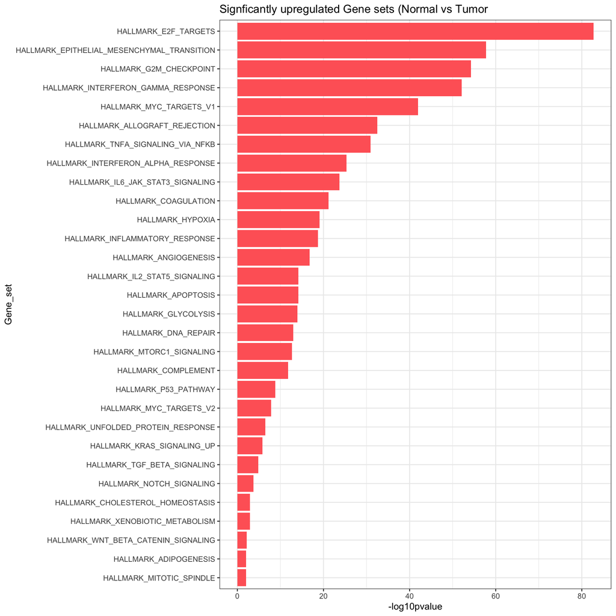

Sign. upregulated Gene sets

```r
#Create the Bar Plot
p <- ggplot(final_df_up,
       aes(x = Gene_set, y = log10p.val)) +
  theme_bw() +
  geom_bar(stat = "identity", fill = "#FF6666") +
  coord_flip()

p + ggtitle ("Signficantly upregulated Gene sets (Normal vs Tumor") +
  ylab("-log10pvalue")
```

```r
#Save as PDF
ggsave(
  file = "Upregulated_genes_bar.pdf",
  plot = last_plot(),
  path = NULL,
  scale = 1,
  width = 10,
  height = 15,
  units = "in",
  dpi = "retina",
  limitsize = TRUE,
  bg = NULL,
)
```

```r
#Change factor lavels to order according to no of genes per Gene set
final_df_down$Gene_set <- factor(final_df_down$Gene_set,
                                 levels = final_df_down$Gene_set
                                 [order(final_df_down$log10p.val)])
```

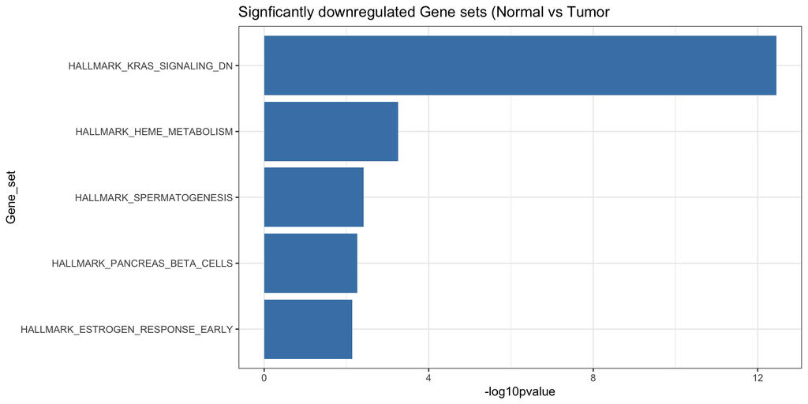

Sign. downregulated Gene sets

```r
#Create the Bar Plot
p_2 <- ggplot(final_df_down,
       aes(x = Gene_set, y = log10p.val)) +
  theme_bw() +
  geom_bar(stat = "identity", fill = "steelblue") +
  coord_flip()

p_2 + ggtitle ("Signficantly downregulated Gene sets (Normal vs Tumor") +
  ylab("-log10pvalue")
```

```r
#Save as PDF
ggsave(
  file = "Downregulated_genes_bar.pdf",
  plot = last_plot(),
  path = NULL,
  scale = 1,
  width = 15,
  height = 10,
  units = "in",
  dpi = "retina",
  limitsize = TRUE,
  bg = NULL,
)
```

# Notes

GSEA 1. Detect general trend without setting limit on differential genes 2. Kolmogorov-Smirnov-Test, multiple hypotheses testing correction 3. MSigDB helps finding other related studies

GAGE (Generally Applicable Gene-set Enrichment) [@GAGE] 1. applies to datasets with any number of sample and is based on a parametric gene randomization procedure [@GAGE] 2. Uses log-based fold changes as per gene statistics 3. assumes gene set comes from a different distribution than the background and unses two-sample t-test to account for the gene set specificic variance as well as the background variance 4. adjusts for different experimental designs and sample sizes by decomposing roup-on group comparison into one-on-one comparisons between samples from different groups - derives a global p-value using a meta-test on the p-values from these comparisons for each gene set 5. separates experimentally perturbed gene sets (from literature, single directions) and canonical pathways (from pathway databases, both directions)

# Useful links:

1. Gage http://bioconductor.org/packages/release/bioc/html/gage.html
2. msigdbr https://cran.r-project.org/web/packages/msigdbr/vignettes/msigdbr-intro.html
3. single cell RNA seq GSEA https://www.nature.com/articles/s41467-020-15298-6

#Data set description

Data retrieved from the [TCBA database](https://www.cancer.gov/about-nci/organization/ccg/research/structural-genomics/tcga) and includes log2-normalized read counts of RNA-sequencing samples from Glioblastoma multiforme (GBM) patients or healthy control tissues.

Tumor tissues were classified as “Primary” or “Recurrent”. Control tissues were classified as being “Normal.”.

I used the updated curated gene set collection Hallmark (H) from the [MSigDB databse](https://www.gsea-msigdb.org/gsea/msigdb/) (@Libzerzon et al.2015).

# Citations

```r
citation("gage")
```

```
##
##
##   Luo, W., Friedman, M., Shedden K., Hankenson, K. and Woolf, P GAGE:
##   Generally Applicable Gene Set Enrichment for Pathways Analysis. BMC
##   Bioinformatics, 2009, 10:161
##
## A BibTeX entry for LaTeX users is
##
##   @Article{,
##     author = {{Luo} and {Weijun} and {Friedman} and {Michael} and {Shedden} and {Kerby} and {Hankenson} and {Kurt} and {Woolf} and {Peter}},
##     title = {GAGE: generally applicable gene set enrichment for pathway analysis},
##     journal = {BMC Bioinformatics},
##     year = {2009},
##     volume = {10},
##     pages = {161},
##   }
##
## This free open-source software implements academic research by the
## authors. Its development took a large amount of extra time and effort.
## If you use it, please support the project by citing the listed journal
## articles.
```

```r
citation("org.Hs.eg.db")
```

```
##
##
##   Marc Carlson (2021). org.Hs.eg.db: Genome wide annotation for Human.
##   R package version 3.14.0.
##
## A BibTeX entry for LaTeX users is
##
##   @Manual{,
##     title = {org.Hs.eg.db: Genome wide annotation for Human},
##     author = {Marc Carlson},
##     year = {2021},
##     note = {R package version 3.14.0},
##   }
##
## ATTENTION: This citation information has been auto-generated from the
## package DESCRIPTION file and may need manual editing, see
## 'help("citation")'.
```

```r
citation("msigdbr")
```

```
##
##
##   Igor Dolgalev (2021). msigdbr: MSigDB Gene Sets for Multiple
##   Organisms in a Tidy Data Format. R package version 7.4.1.
##   https://CRAN.R-project.org/package=msigdbr
##
## A BibTeX entry for LaTeX users is
##
##   @Manual{,
##     title = {msigdbr: MSigDB Gene Sets for Multiple Organisms in a Tidy Data Format},
##     author = {Igor Dolgalev},
##     year = {2021},
##     note = {R package version 7.4.1},
##     url = {https://CRAN.R-project.org/package=msigdbr},
##   }
```